# 08 - Datos Cuantitativos

Alonso Pizarro Lagunas

5/11/2021

# Datos cuantitativos

- Ejemplo 1

```r
edad <- c(15,18,25,40,30,29,56,40,13,27,42,23,11,26,25,32,30,40,33,29)
table(edad)              # Frecuencias absolutas
```

```
## edad
## 11 13 15 18 23 25 26 27 29 30 32 33 40 42 56
##  1  1  1  1  1  2  1  1  2  2  1  1  3  1  1
```

```r
prop.table(table(edad))  # Frecuencias relativas
```

```
## edad
##   11   13   15   18   23   25   26   27   29   30   32   33   40   42   56
## 0.05 0.05 0.05 0.05 0.05 0.10 0.05 0.05 0.10 0.10 0.05 0.05 0.15 0.05 0.05
```

```r
cumsum(table(edad))      # Frecuencias acumuladas
```

```
## 11 13 15 18 23 25 26 27 29 30 32 33 40 42 56
##  1  2  3  4  5  7  8  9 11 13 14 15 18 19 20
```

```r
cumsum(prop.table(table(edad)))  # Frecuencias relativas acumuladas
```

```
##   11   13   15   18   23   25   26   27   29   30   32   33   40   42   56
## 0.05 0.10 0.15 0.20 0.25 0.35 0.40 0.45 0.55 0.65 0.70 0.75 0.90 0.95 1.00
```

- Ejemplo 2

  ```
  - Ejemplo con dados.
  ```

```r
set.seed(161720)
dados <- sample(1:6,25, replace = TRUE)
dados
```

```
##  [1] 6 1 1 3 5 2 6 3 5 6 2 6 4 5 2 5 3 6 1 4 6 6 6 6 2
```

```r
table(dados) # frecuencia absoluta
```

```
## dados
## 1 2 3 4 5 6
## 3 4 3 2 4 9
```

```r
prop.table(table(dados)) # frecuencia relativa
```

```
## dados
##    1    2    3    4    5    6
## 0.12 0.16 0.12 0.08 0.16 0.36
```

```r
cumsum(table(dados)) # frecuencia absoluta acumulada
```

```
##  1  2  3  4  5  6
##  3  7 10 12 16 25
```

```r
cumsum(prop.table(table(dados))) # frecuencia relativa acumulada
```

```
##    1    2    3    4    5    6
## 0.12 0.28 0.40 0.48 0.64 1.00
```

- Construyendo un data frame con los datos con la stablas anteriores. Transformamos a vector para no arrastrar la primera fila.

```r
dados.df <- data.frame(Puntuacion = 1:6,
                       Fr.Abs = as.vector(table(dados)),
                       Fr.Rel = as.vector(prop.table(table(dados))),
                       Fr.Abs.Cum = as.vector(cumsum(table(dados))),
                       Fr.Rel.Cum = as.vector(cumsum(prop.table(table(dados)))))
dados.df
```

```
##   Puntuacion Fr.Abs Fr.Rel Fr.Abs.Cum Fr.Rel.Cum
## 1          1      3   0.12          3       0.12
## 2          2      4   0.16          7       0.28
## 3          3      3   0.12         10       0.40
## 4          4      2   0.08         12       0.48
## 5          5      4   0.16         16       0.64
## 6          6      9   0.36         25       1.00
```

# Medidas de tendencia central o centralización

```r
sort(edad)  # 'lista' de valores ordenados
```

```
##  [1] 11 13 15 18 23 25 25 26 27 29 29 30 30 32 33 40 40 40 42 56
```

```r
moda <- as.numeric(names(table(edad)[which(table(edad) == max(table(edad)))])) # moda
mediana <- median(edad)
media <- mean(edad)
```

- La *moda* es 40, la *mediana* es 29 y la *media* es 29.2

## Las diferentes medias

```r
x <- c(32,45,67,43,28,17,48,95)
n <- length(x)
```

- El vector es 32, 45, 67, 43, 28, 17, 48, 95 cuya longitud es 8 observaciones.

#### Algunas fórmulas

- *Media*:
  $$\bar{x}= \frac{1}{n} \sum_{i=1}^n x_i$$

```r
sum(x)/n
```

```
## [1] 46.875
```

- *Media ponderada*:
  $$\bar{X}_w = \frac{X_1w_1 + X_2w_2 + ...+X_nw_n}{w_1 + w_2 +...+w_n} = \frac{\sum_{i=1}^n X_i \cdot w_i}{\sum_{i = 1}^n w_i}$$

```r
w = c(1,2,2,3,3,2,2,1)
sum(x*w)/sum(w)
```

```
## [1] 43.375
```

- *Media geométrica*:
  $$\bar{X}_g= \left(\prod_{i=1}^n x_i\right)^{1/n}$$

```r
prod(x)^(1/n)
```

```
## [1] 41.62073
```

- *Media armónica*:
  $$\bar{x}_A= \frac{n}{\sum_{i=i}^n \frac{1}{x_i}}$$

```r
n/sum(1/x)
```

```
## [1] 36.77301
```

# Medidas de posición

## Cuantiles

```r
set.seed(260798)
dado = sample(1:4, 50, replace = T)
length(dado)
```

```
## [1] 50
```

```r
# Ordenamos los dado
dado = sort(dado)

# Cuantile 0.3

dado[15]
```

```
## [1] 1
```

- Cuartiles $Q_{0.25}$, $Q_{0.5}$ y $Q_{0.75}$. Son los llamados primer, segundo y tercer cuartil. El primer cuartril es mayor o igual a un cuarta parte de la muestra.
- Los deciles son los cuantiles $Q_p$ con $p$ múltiplo de 0.1.
- Los percentiles son los cuantiles $Q_p$ con $p$ múltiplo de 0.01.
  - Ejemplo

```r
set.seed(0)
dados2 = sample(1:6,15, replace = TRUE)
dados2
```

```
##  [1] 6 1 4 1 2 5 3 6 2 3 3 1 5 5 2
```

```r
set.seed(NULL)
quantile(dados2,0.25) # Primer Cuartil
```

```
## 25%
##   2
```

```r
quantile(dados2, 0.8) # Octavo Decil
```

```
## 80%
##   5
```

# Medidas de dispersión

- Rango o recorrido `diff(range(x))`
- Rango Intercuartílico `IQR(x,type = ...)`
- Varianza `var(x)`
- Desviación típica `sd(x)`
- Varianza muestral `var(x)*(length(x)-1)/length(x)`
- Desviación típica muestral `sd(x)*sqrt((length(x)-1)/length(x))`

```r
diff(range(dados2)) # Rango
```

```
## [1] 5
```

```r
IQR(dados2) # rango intercuartílico
```

```
## [1] 3
```

```r
var(dados2) # Varianza
```

```
## [1] 3.209524
```

```r
sd(dados2) # desviación típica
```

```
## [1] 1.791514
```

```r
n = length(dados2)
var(dados2)*(n-1)/n   # Varianza muestral
```

```
## [1] 2.995556
```

```r
sd(dados2)*sqrt((n-1)/n) # sd muestral
```

```
## [1] 1.730767
```

### Funciones interesantes para trabajar con variables cuantitativas

- Resumen estadístico `summary(x)`

```r
cangrejos = read.table("../../data/datacrab.txt", header = T)
cangrejos = cangrejos[,-1]
summary(cangrejos)
```

```
##      color           spine           width          satell           weight
##  Min.   :2.000   Min.   :1.000   Min.   :21.0   Min.   : 0.000   Min.   :1200
##  1st Qu.:3.000   1st Qu.:2.000   1st Qu.:24.9   1st Qu.: 0.000   1st Qu.:2000
##  Median :3.000   Median :3.000   Median :26.1   Median : 2.000   Median :2350
##  Mean   :3.439   Mean   :2.486   Mean   :26.3   Mean   : 2.919   Mean   :2437
##  3rd Qu.:4.000   3rd Qu.:3.000   3rd Qu.:27.7   3rd Qu.: 5.000   3rd Qu.:2850
##  Max.   :5.000   Max.   :3.000   Max.   :33.5   Max.   :15.000   Max.   :5200
```

```r
summary(subset(cangrejos, color == 3, c("weight","width")))
```

```
##      weight         width
##  Min.   :1300   Min.   :22.5
##  1st Qu.:2100   1st Qu.:25.1
##  Median :2500   Median :26.5
##  Mean   :2538   Mean   :26.7
##  3rd Qu.:3000   3rd Qu.:28.2
##  Max.   :5200   Max.   :33.5
```

```r
summary(subset(cangrejos, color == 5, c("weight","width")))
```

```
##      weight         width
##  Min.   :1300   Min.   :21.00
##  1st Qu.:1900   1st Qu.:23.90
##  Median :2125   Median :25.50
##  Mean   :2174   Mean   :25.28
##  3rd Qu.:2400   3rd Qu.:26.57
##  Max.   :3225   Max.   :29.30
```

- Función by() para aplicar una determinada función a algunas columnas de un df segmentando por niveles de un factor `by(columnas, factor, FUN = función)`

```r
by(iris[,c(1,3)], iris$Species, FUN = summary)
```

```
## iris$Species: setosa
##   Sepal.Length    Petal.Length
##  Min.   :4.300   Min.   :1.000
##  1st Qu.:4.800   1st Qu.:1.400
##  Median :5.000   Median :1.500
##  Mean   :5.006   Mean   :1.462
##  3rd Qu.:5.200   3rd Qu.:1.575
##  Max.   :5.800   Max.   :1.900
## ------------------------------------------------------------
## iris$Species: versicolor
##   Sepal.Length    Petal.Length
##  Min.   :4.900   Min.   :3.00
##  1st Qu.:5.600   1st Qu.:4.00
##  Median :5.900   Median :4.35
##  Mean   :5.936   Mean   :4.26
##  3rd Qu.:6.300   3rd Qu.:4.60
##  Max.   :7.000   Max.   :5.10
## ------------------------------------------------------------
## iris$Species: virginica
##   Sepal.Length    Petal.Length
##  Min.   :4.900   Min.   :4.500
##  1st Qu.:6.225   1st Qu.:5.100
##  Median :6.500   Median :5.550
##  Mean   :6.588   Mean   :5.552
##  3rd Qu.:6.900   3rd Qu.:5.875
##  Max.   :7.900   Max.   :6.900
```

- Función `aggregate` y ``by` son equivalentes, pero se visualizan distinto

```r
aggregate(cbind(Sepal.Length, Petal.Length)~Species, data = iris, FUN = summary)
```

```
##      Species Sepal.Length.Min. Sepal.Length.1st Qu. Sepal.Length.Median
## 1     setosa             4.300                4.800               5.000
## 2 versicolor             4.900                5.600               5.900
## 3  virginica             4.900                6.225               6.500
##   Sepal.Length.Mean Sepal.Length.3rd Qu. Sepal.Length.Max. Petal.Length.Min.
## 1             5.006                5.200             5.800             1.000
## 2             5.936                6.300             7.000             3.000
## 3             6.588                6.900             7.900             4.500
##   Petal.Length.1st Qu. Petal.Length.Median Petal.Length.Mean
## 1                1.400               1.500             1.462
## 2                4.000               4.350             4.260
## 3                5.100               5.550             5.552
##   Petal.Length.3rd Qu. Petal.Length.Max.
## 1                1.575             1.900
## 2                4.600             5.100
## 3                5.875             6.900
```

## Diagramas de caja y bigotes

- Ejemplo caja de bigotes mediante la función `boxplot`

```r
quantile(dados, 0.25)
```

```
## 25%
##   2
```

```r
quantile(dados,0.5)
```

```
## 50%
##   5
```

```r
quantile(dados, 0.75)
```

```
## 75%
##   6
```

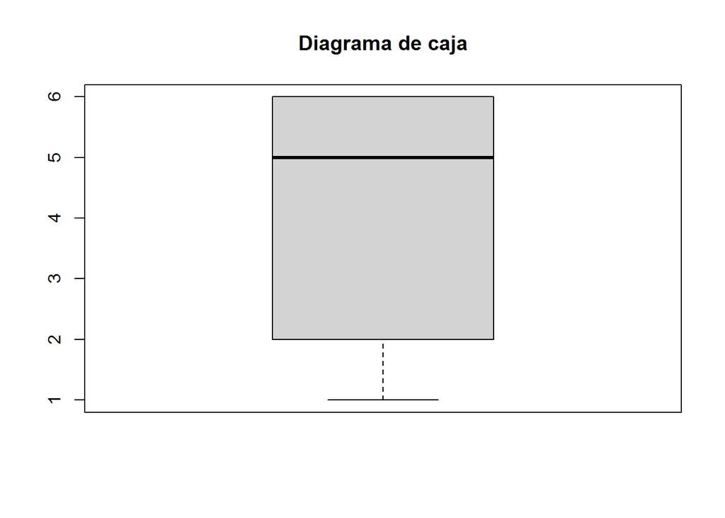

```r
boxplot(dados, main = "Diagrama de caja") # distribución de una variable
```

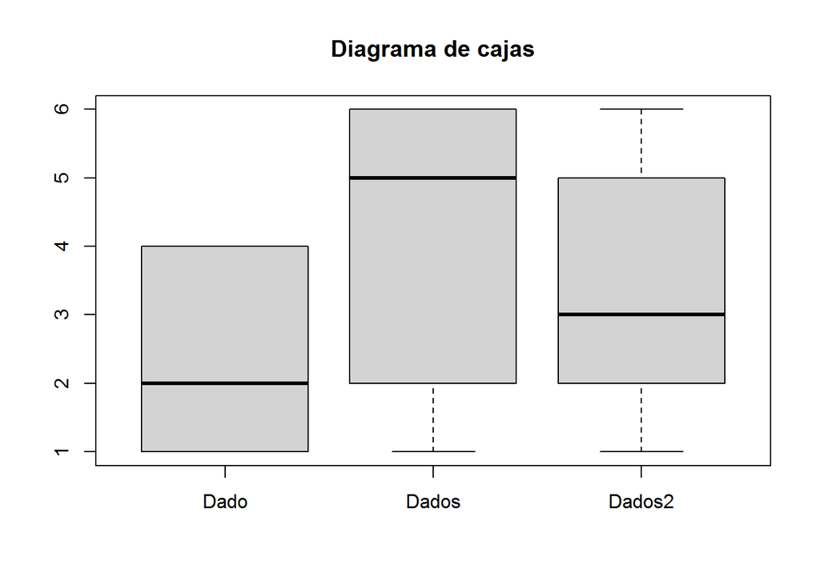

```r
boxplot(dado, dados, dados2, main = "Diagrama de cajas", names = c("Dado","Dados","Dados2") )
```

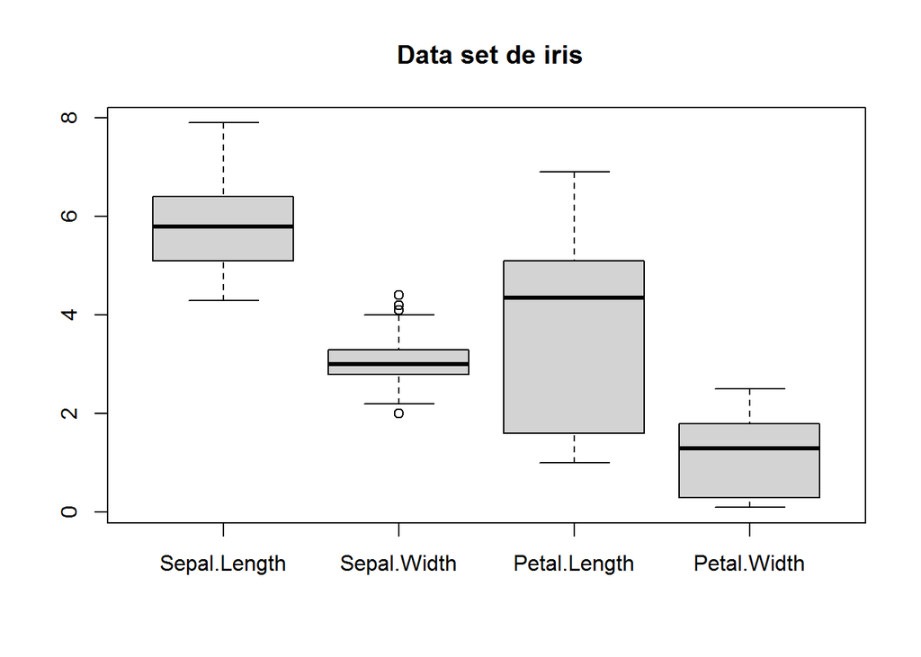

```r
# Boxplot de un Dataframe

boxplot(iris[,-5], main = " Data set de iris")
```

### Configuración de boxplot

```r
body <- read.table("../../data/bodyfat.txt", header = T)
str(body)
```

```
## 'data.frame':    252 obs. of  15 variables:
##  $ Density: num  1.07 1.09 1.04 1.08 1.03 ...
##  $ Fat    : num  12.3 6.1 25.3 10.4 28.7 20.9 19.2 12.4 4.1 11.7 ...
##  $ Age    : int  23 22 22 26 24 24 26 25 25 23 ...
##  $ Weight : num  154 173 154 185 184 ...
##  $ Height : num  67.8 72.2 66.2 72.2 71.2 ...
##  $ Neck   : num  36.2 38.5 34 37.4 34.4 39 36.4 37.8 38.1 42.1 ...
##  $ Chest  : num  93.1 93.6 95.8 101.8 97.3 ...
##  $ Abdomen: num  85.2 83 87.9 86.4 100 94.4 90.7 88.5 82.5 88.6 ...
##  $ Hip    : num  94.5 98.7 99.2 101.2 101.9 ...
##  $ Thigh  : num  59 58.7 59.6 60.1 63.2 66 58.4 60 62.9 63.1 ...
##  $ Knee   : num  37.3 37.3 38.9 37.3 42.2 42 38.3 39.4 38.3 41.7 ...
##  $ Ankle  : num  21.9 23.4 24 22.8 24 25.6 22.9 23.2 23.8 25 ...
##  $ Biceps : num  32 30.5 28.8 32.4 32.2 35.7 31.9 30.5 35.9 35.6 ...
##  $ Forearm: num  27.4 28.9 25.2 29.4 27.7 30.6 27.8 29 31.1 30 ...
##  $ Wrist  : num  17.1 18.2 16.6 18.2 17.7 18.8 17.7 18.8 18.2 19.2 ...
```

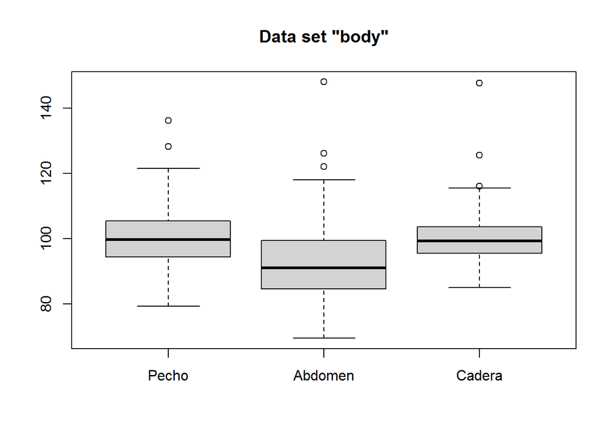

```r
boxplot(body[,7:9], main = "Data set \"body\"", names = c("Pecho", "Abdomen","Cadera"))
```

- Si quisiera una comparativa dentro de la misma variable cuantitativa en función de niveles de un factor, indicamos `boxplot(var.num ~factor, data = df)`

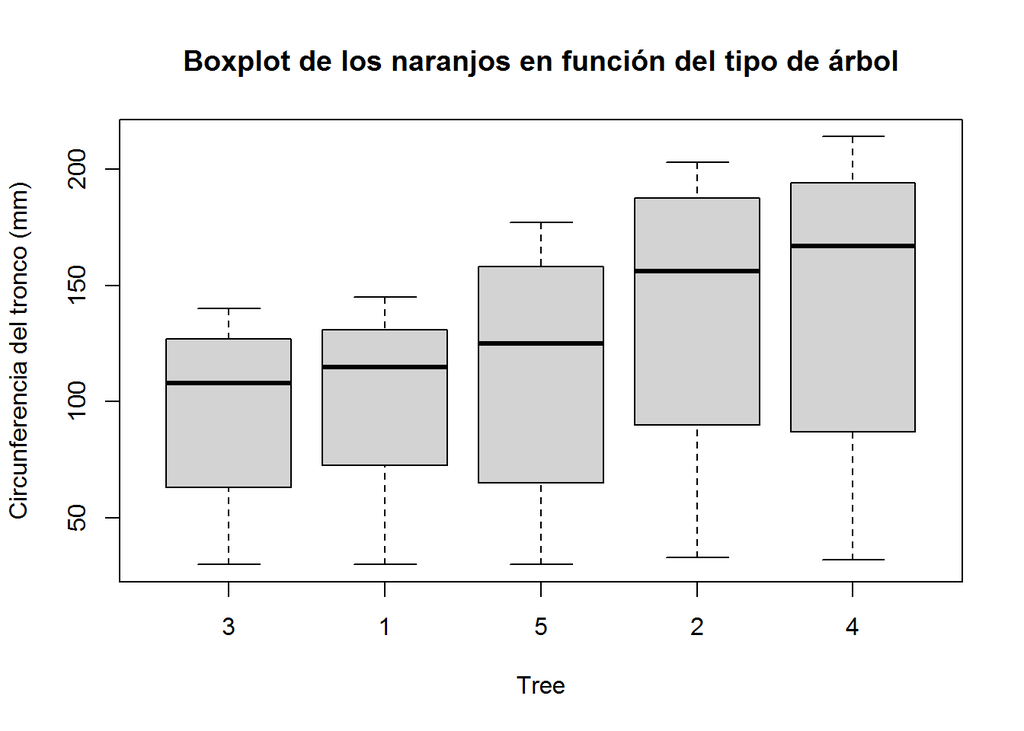

```r
boxplot(circumference ~ Tree, data = Orange, ylab = "Circunferencia del tronco (mm)", main = "Boxplot de los naranjos en función del tipo de árbol" )
```

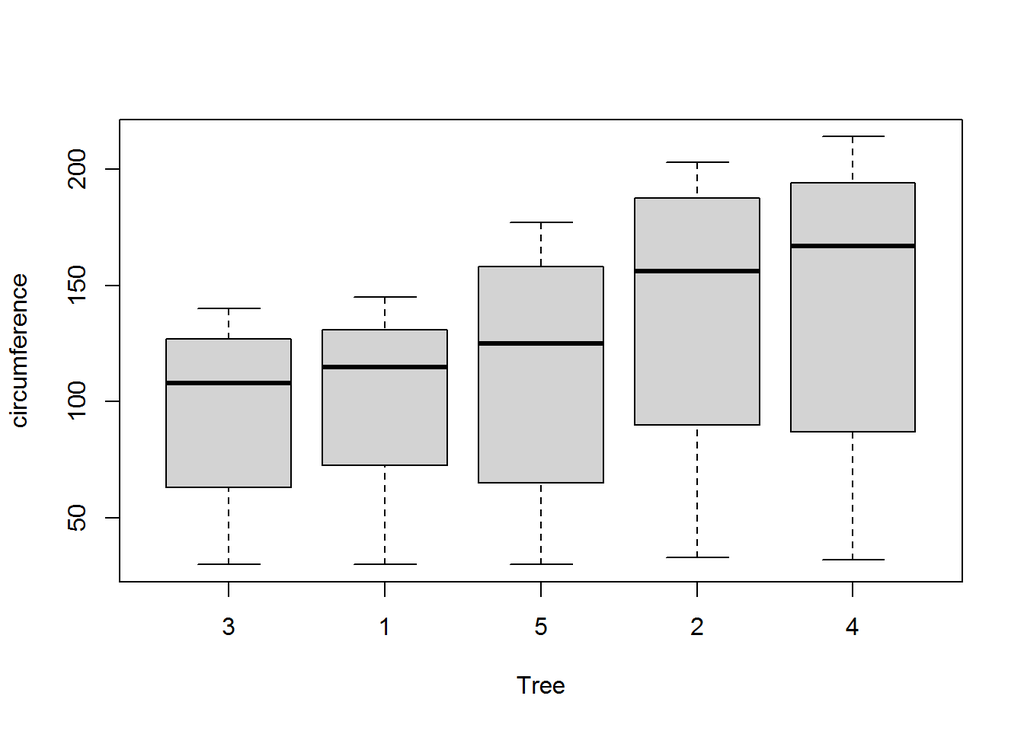

```
## List of 6
##  $ stats: num [1:5, 1:5] 30 63 108 127 140 30 72.5 115 131 145 ...
##  $ n    : num [1:5] 7 7 7 7 7
##  $ conf : num [1:2, 1:5] 69.8 146.2 80.1 149.9 69.5 ...
##  $ out  : num(0)
##  $ group: num(0)
##  $ names: chr [1:5] "3" "1" "5" "2" ...
```

```r
str(boxplot(circumference ~ Tree, data = Orange))
```

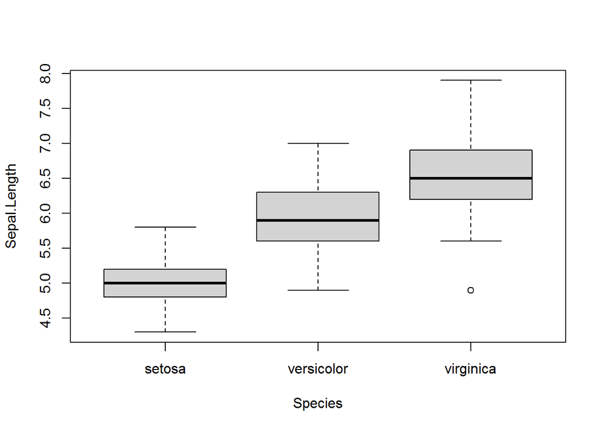

```r
boxplot(Sepal.Length ~ Species, data =iris)  # iris
```

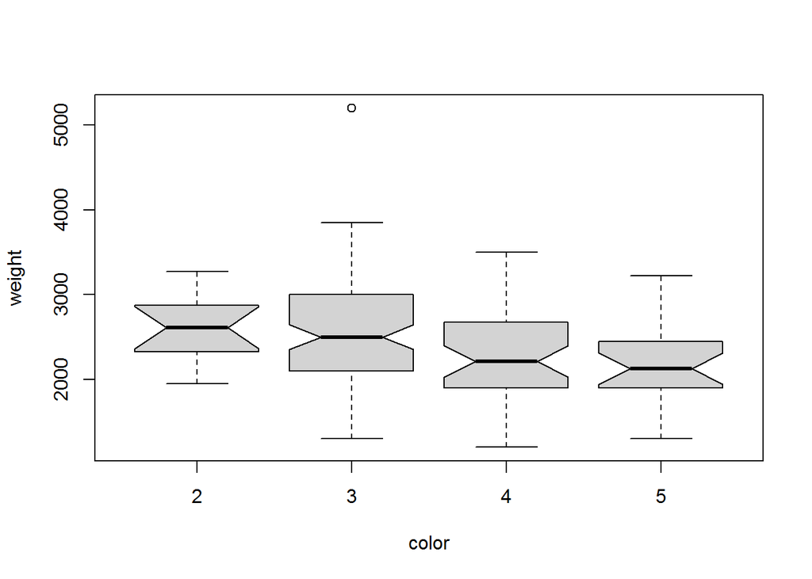

```r
boxplot(weight~color, notch = T ,data = cangrejos) # cangrejos
```

# Ejemplo del insecticida

- **InsectSprays dataset**: Effectiveness of Insect Sprays. The counts of insects in agricultural experimental units treated with different insecticides.

```r
str(InsectSprays)
```

```
## 'data.frame':    72 obs. of  2 variables:
##  $ count: num  10 7 20 14 14 12 10 23 17 20 ...
##  $ spray: Factor w/ 6 levels "A","B","C","D",..: 1 1 1 1 1 1 1 1 1 1 ...
```

```r
head(InsectSprays)
```

```
##   count spray
## 1    10     A
## 2     7     A
## 3    20     A
## 4    14     A
## 5    14     A
## 6    12     A
```

- Un resumen de los sprays

```r
by(InsectSprays$count, InsectSprays$spray, FUN = summary)
```

```
## InsectSprays$spray: A
##    Min. 1st Qu.  Median    Mean 3rd Qu.    Max.
##    7.00   11.50   14.00   14.50   17.75   23.00
## ------------------------------------------------------------
## InsectSprays$spray: B
##    Min. 1st Qu.  Median    Mean 3rd Qu.    Max.
##    7.00   12.50   16.50   15.33   17.50   21.00
## ------------------------------------------------------------
## InsectSprays$spray: C
##    Min. 1st Qu.  Median    Mean 3rd Qu.    Max.
##   0.000   1.000   1.500   2.083   3.000   7.000
## ------------------------------------------------------------
## InsectSprays$spray: D
##    Min. 1st Qu.  Median    Mean 3rd Qu.    Max.
##   2.000   3.750   5.000   4.917   5.000  12.000
## ------------------------------------------------------------
## InsectSprays$spray: E
##    Min. 1st Qu.  Median    Mean 3rd Qu.    Max.
##    1.00    2.75    3.00    3.50    5.00    6.00
## ------------------------------------------------------------
## InsectSprays$spray: F
##    Min. 1st Qu.  Median    Mean 3rd Qu.    Max.
##    9.00   12.50   15.00   16.67   22.50   26.00
```

- Una medida de dispersión

```r
aggregate(count~spray, data = InsectSprays, FUN = sd)
```

```
##   spray    count
## 1     A 4.719399
## 2     B 4.271115
## 3     C 1.975225
## 4     D 2.503028
## 5     E 1.732051
## 6     F 6.213378
```

- Una gráfica de cajas

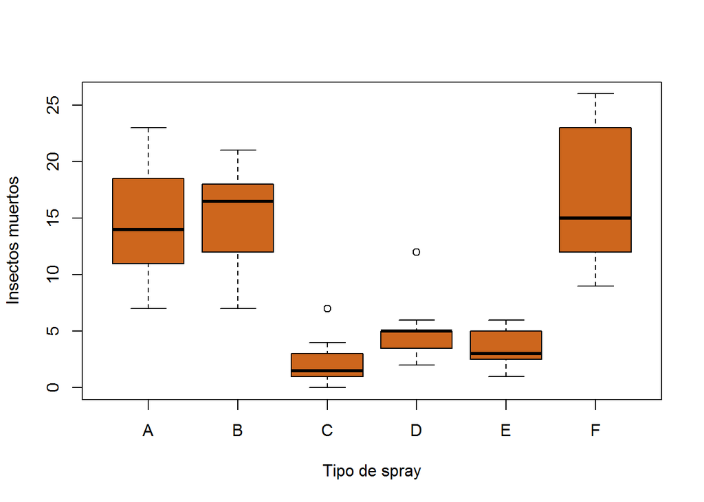

```r
boxplot(count~spray, data=InsectSprays, col = "chocolate3", ylab = "Insectos muertos", xlab = "Tipo de spray")
```